## I. Overview

This script performs initial data cleanining, visualization, and basic analysis for five test sites in the Logan River Observatory network. These sites include:

- Logan River at Franklin Basin (discharge, water temp)
- Logan River at Main Street (discharge, water temp)
- Logan River at Mendon (discharge, water temp)
- Franklin Basin Climate Station (Precipitation, Air temp)
- Logan River Golf Course Climate Station (Precipitation, Air temp)

Data for all five sites were downloaded on 10/26/2025 at 3:30 MST as individual .csv files from the LRO Hydroserver page (https://lro.hydroserver.org/browse)

This script performs the following actions:

1. Read in and clean data files
2. Combine data files for easier plotting
3. Plotting and basic analysis

## II. Read in and clean data files

Make list of all data files in data folder (includes all sites + parameters listed above):

```r
fileNames <- list.files(here("data"), full.names = T)
```

Read in data and store in a list:

```r
dataList <- list() #empty list to receive data
mdList <- list() #empty list to receive metadata


for(i in 1:length(fileNames)){ #loop over fileNames vector
  mdTemp<-read.csv(fileNames[i], col.names = c("C1")) #read in "ith" file

  mdTemp1<-mdTemp%>%
    mutate(rownum = c(1:nrow(mdTemp)))%>% #add rownum column
    filter(rownum == 11 | rownum == 57 |rownum == 65)%>% #extract desired metadata rows (station name, parameter name)
    mutate(metadata = substr(C1, 9, nchar(C1)))%>% #remove "# Name:" from beginning of metadata entries
    select(metadata, rownum)%>% #drop extra cols
    pivot_wider(names_from = rownum, values_from = metadata)%>% #pivot wider to get columns for site name and parameter
    rename(siteName = 1, parameter = 2, units =3)%>% #add column names
    mutate(dataRef = i) #add reference column for later merge

  mdList[[i]] <- mdTemp1 #store as "ith" item in metadata list

  dataList[[i]]<-read.csv(fileNames[i], skip = 81)%>% #read in "ith" file, skipping 81 lines of metadata
    mutate(dataRef = i)%>% #add reference column for merge with metadata
    mutate(date = substr(ResultTime, 1, 10), #extract date from ResultTime column
           time = substr(ResultTime, 12, 19), #extract time from ResultTime column
           dateTime = ymd_hms(paste(date, time, sep = " ")))%>% #create new dateTime column in POSIXct format
    rename(parameterValue = Result)%>% #rename result column
    select(parameterValue, ResultQualifiers, dateTime, dataRef) #drop extra cols
}


head(dataList[[10]]) #check outputs
```

```
##   parameterValue ResultQualifiers            dateTime dataRef
## 1         -0.814                  2017-01-20 23:00:00      10
## 2         -0.941                  2017-01-20 23:15:00      10
## 3         -1.104                  2017-01-20 23:30:00      10
## 4         -1.175                  2017-01-20 23:45:00      10
## 5         -1.280                  2017-01-21 00:00:00      10
## 6         -1.331                  2017-01-21 00:15:00      10
```

```r
head(mdList[[10]])
```

```
## # A tibble: 1 × 4
##   siteName                                   parameter   units          dataRef
##   <chr>                                      <chr>       <chr>            <int>
## 1 Climate Station at Logan River Golf Course Temperature degree celsius      10
```

## II. Combine data files for easier plotting

```r
mdAll <-mdList%>%
  bind_rows()#rbind all metadata files into 1 DF
dataAll <-dataList%>%
  bind_rows()#rbind all data files into 1 DF

fullData <- merge(mdAll, dataAll) #merge metadata and data by dataRef column

head(fullData)
```

```
##   dataRef                        siteName parameter                 units
## 1       1 Logan River near Franklin Basin Discharge cubic feet per second
## 2       1 Logan River near Franklin Basin Discharge cubic feet per second
## 3       1 Logan River near Franklin Basin Discharge cubic feet per second
## 4       1 Logan River near Franklin Basin Discharge cubic feet per second
## 5       1 Logan River near Franklin Basin Discharge cubic feet per second
## 6       1 Logan River near Franklin Basin Discharge cubic feet per second
##   parameterValue ResultQualifiers            dateTime
## 1       63.30597             <NA> 2014-06-20 20:30:00
## 2       63.90575             <NA> 2014-06-20 20:45:00
## 3       63.68730             <NA> 2014-06-20 21:00:00
## 4       62.11003             <NA> 2014-06-20 21:15:00
## 5       62.31796             <NA> 2014-06-20 21:30:00
## 6       61.60249             <NA> 2014-06-20 21:45:00
```

```r
tail(fullData)
```

```
##         dataRef                                   siteName     parameter
## 4287705      12 Climate Station at Logan River Golf Course Precipitation
## 4287706      12 Climate Station at Logan River Golf Course Precipitation
## 4287707      12 Climate Station at Logan River Golf Course Precipitation
## 4287708      12 Climate Station at Logan River Golf Course Precipitation
## 4287709      12 Climate Station at Logan River Golf Course Precipitation
## 4287710      12 Climate Station at Logan River Golf Course Precipitation
##              units parameterValue ResultQualifiers            dateTime
## 4287705 centimeter       43.38865                  2024-12-04 18:45:00
## 4287706 centimeter       43.38865                  2024-12-04 19:00:00
## 4287707 centimeter       43.38865                  2024-12-04 19:15:00
## 4287708 centimeter       43.38865                  2024-12-04 19:30:00
## 4287709 centimeter       43.38865                  2024-12-04 19:45:00
## 4287710 centimeter       43.38865                  2024-12-04 20:00:00
```

## III. Basic plotting & analysis

### A. Discharge

Starting with a basic time series, y = discharge CFS, x = date Time, color = site.

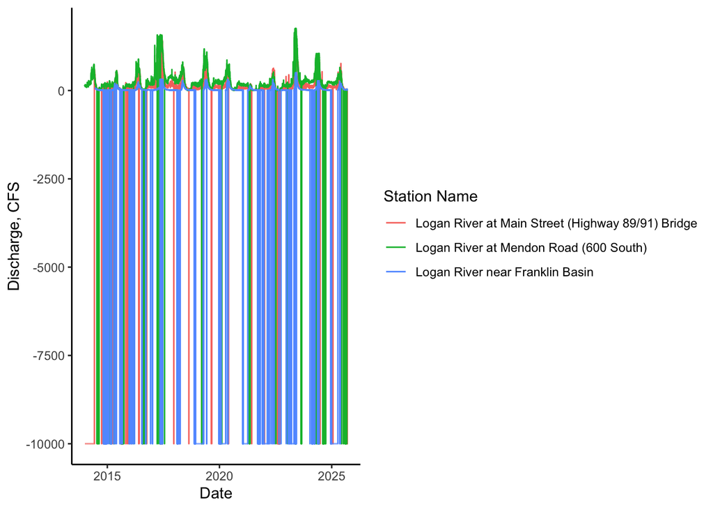

```r
q.comb <- ggplot(
  filter(fullData, parameter == "Discharge"),
  aes(x = dateTime, y = parameterValue, color = siteName)
)+
  geom_line()+
  theme_classic()+
  labs(x = "Date", y = "Discharge, CFS", color = "Station Name")
q.comb
```

Appear to be some major data issues - significant negative readings, especially at FB and Main St sites. Try removing all negative values:

```r
noNeg <- fullData%>%
  filter(!(parameter=="Discharge"&parameterValue<0)) #drop discharge values <0
```

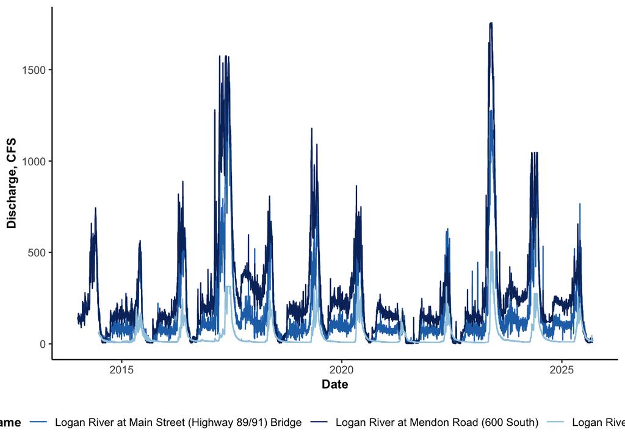

```r
#color palate:

discharge.pal <- c("#2171B5", "#08306B",  "#9ECAE1")

#Check with updated plot:
q.cor <- ggplot(
  filter(noNeg, parameter == "Discharge"),
  aes(x = dateTime, y = parameterValue, color = siteName)
)+
  geom_line()+
  theme_classic()+
  labs(x = "Date", y = "Discharge, CFS", color = "Station Name")+
  scale_color_manual(values = discharge.pal)+
  theme(legend.position = "bottom",
        axis.title = element_text(size = 10, face = "bold"),
        legend.title = element_text(size = 10, face = "bold"))

q.cor
```

```r
#Save:

ggsave("Discharge_Comb.jpg", q.cor, device = "jpeg", path = here("outputs", "plots"), units = "in", dpi = "retina", height = 6, width = 11)
```

### B. Water Temperature

First, filter out stream sites:

```r
streamData <- noNeg%>%
  filter(!str_detect(siteName, "Climate")) #drop all sites that have "Climate" in the name

unique(streamData$siteName) #check if successful
```

```
## [1] "Logan River near Franklin Basin"
## [2] "Logan River at Main Street (Highway 89/91) Bridge"
## [3] "Logan River at Mendon Road (600 South)"
```

```r
unique(streamData$parameter) #check available parameters
```

```
## [1] "Discharge"   "Temperature"
```

Plotting:

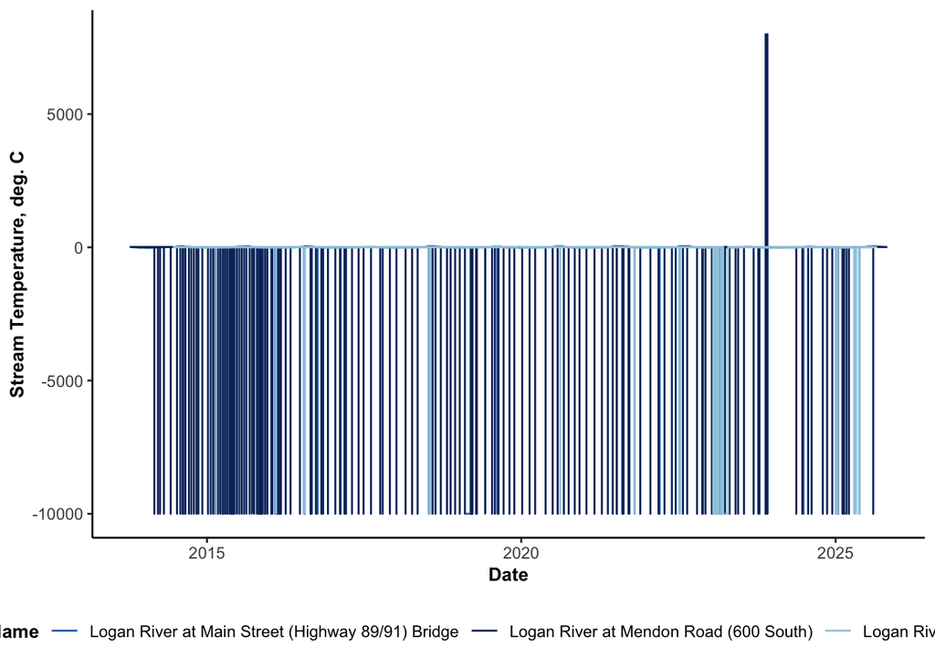

```r
#Initial plot:
stream.temp <- ggplot(
  filter(streamData,
         parameter == "Temperature"),
  aes(x = dateTime, y = parameterValue, color = siteName)
)+
  geom_line()+
  theme_classic()+
  labs(x = "Date", y = "Stream Temperature, deg. C", color = "Station Name")+
  scale_color_manual(values = discharge.pal)+
  theme(legend.position = "bottom",
        axis.title = element_text(size = 10, face = "bold"),
        legend.title = element_text(size = 10, face = "bold"))

stream.temp
```

Pretty major issues - checking some basic stats:

```r
summary(
  filter(streamData, parameter == "Temperature")$parameterValue
)
```

```
##     Min.  1st Qu.   Median     Mean  3rd Qu.     Max.
## -9999.00     3.49     5.88  -120.99     9.03  7999.00
```

```r
streamCor <- streamData%>%
  mutate(
    parameterValue = case_when(parameter=="Temperature"&parameterValue<(0-20)~NA, #replace all stream temps < -20 with NA
                               parameter=="Temperature"&parameterValue>50~NA, #replace all stream temps > 25 with NA
                               .default = parameterValue)
  )

summary(
  filter(streamCor, parameter == "Temperature")$parameterValue #check results
)
```

```
##    Min. 1st Qu.  Median    Mean 3rd Qu.    Max.    NA's
##  -0.150   3.570   5.930   6.808   9.070  28.270   22345
```

Seems to work for low outliers, possibly some exposures on the high end (82 deg F for a water temp seems unlikely).

Checking results with a plot:

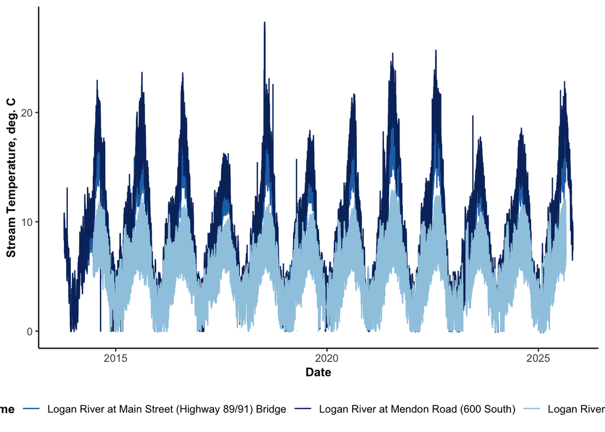

```r
#Corrected plot:
stream.cor <- ggplot(
  filter(streamCor,
         parameter == "Temperature"),
  aes(x = dateTime, y = parameterValue, color = siteName)
)+
  geom_line()+
  theme_classic()+
  labs(x = "Date", y = "Stream Temperature, deg. C", color = "Station Name")+
  scale_color_manual(values = discharge.pal)+
  theme(legend.position = "bottom",
        axis.title = element_text(size = 10, face = "bold"),
        legend.title = element_text(size = 10, face = "bold"))

stream.cor
```

```r
#Save:

ggsave("StreamTemp_Comb.jpg", stream.cor, device = "jpeg", path = here("outputs", "plots"), units = "in", dpi = "retina", height = 6, width = 11)
```

Looks much better - Still likely some outliers or logger exposures on the upper end, but at least a coherent plot.